# Module characterisation

A module from `06_Module_Building` is a list of co-varying proteins with a colour for a name. This step says what each module is, three ways: which gene sets its members over-represent, which members follow it most closely, and whether its members interact with each other more than chance in STRING, a database of known and predicted protein interactions.

## Packages

clusterProfiler runs the enrichment and STRINGdb the interaction test. tidygraph, ggraph and igraph draw the networks and are called with `::`.

```r
library(here)
library(dplyr)
library(tibble)
library(tidyr)
library(purrr)
library(ggplot2)
library(clusterProfiler)
library(STRINGdb)
library(patchwork)
source(here("00_Setup", "Shared_functions", "workbooks.R"))
string_dir <- "01_Processing/07_Module_Characterisation/references/STRING"
inputs <- c(
  modules = "01_Processing/06_Module_Building/c_data/module_building.rds",
  gene_sets = "01_Processing/04_Gene_Sets/c_data/gene_sets.rds",
  string_links = file.path(string_dir, "9606.protein.links.v12.0.min700.txt.gz"),
  string_aliases = file.path(string_dir, "9606.protein.aliases.v12.0.txt.gz"),
  string_info = file.path(string_dir, "9606.protein.info.v12.0.txt.gz")
)
paths <- vapply(inputs, here, character(1))
stopifnot(file.exists(paths))
```

The modules and their kME, the tested gene sets (disease sets already removed in `04_Gene_Sets`), and three STRING v12.0 files kept in `references/STRING/` (source and version in `references/README.md`).

```r
modules <- readRDS(paths[["modules"]])
gs <- readRDS(paths[["gene_sets"]])
members <- filter(modules$membership, module != "grey")
count(members, module, name = "n_proteins") |> arrange(desc(n_proteins))
```

```
# A tibble: 10 × 2
   module    n_proteins
   <chr>          <int>
 1 turquoise        340
 2 blue             330
 3 brown            249
 4 yellow           211
 5 green            168
 6 red              167
 7 black            109
 8 pink             104
 9 magenta           82
10 purple            70
```

## Gene-set enrichment

Over-representation analysis (ORA) asks, per module and per set, whether more of the module’s genes fall in the set than a random draw of the same size would give. The test is hypergeometric (clusterProfiler’s `enricher()`, run for every module by `compareCluster()`). The universe is the 2058 measured genes, one per symbol: testing against the whole genome would reward any module for being muscle. Only the protein that represents its gene in `04_Gene_Sets` enters, so a symbol is never counted twice. Sets keep the 15-to-500 size rule. `enricher()` returns only sets holding at least one of the module’s genes, and Benjamini-Hochberg (BH) correction runs over those, within each module. Its effective universe is the measured genes that belong to at least one set.

```r
term2gene <- enframe(gs$sets, "set_id", "gene") |> unnest(gene)
ora_members <- filter(members, uniprot_id %in% gs$protein_map$uniprot_id[gs$protein_map$selected])
c(members = nrow(members), entering_ora = nrow(ora_members))
```

```
     members entering_ora
        1830         1829
```

```r
ora_fit <- compareCluster(
  split(ora_members$gene, ora_members$module),
  fun = "enricher", TERM2GENE = term2gene, universe = gs$gene_universe,
  minGSSize = 15, maxGSSize = 500, pvalueCutoff = 1, qvalueCutoff = 1
)
ora <- as_tibble(ora_fit) |>
  transmute(
    module = as.character(Cluster), set_id = ID, gene_ratio = GeneRatio, bg_ratio = BgRatio,
    n_overlap = Count, p = pvalue, fdr = p.adjust
  ) |>
  left_join(select(gs$set_catalog, set_id, collection, pathway), by = "set_id")
ora |>
  slice_min(p, n = 1, by = module, with_ties = FALSE) |>
  select(module, pathway, gene_ratio, fdr)
```

```
# A tibble: 10 × 4
   module    pathway                                        gene_ratio       fdr
   <chr>     <chr>                                          <chr>          <dbl>
 1 black     REACTOME_STRIATED_MUSCLE_CONTRACTION           24/103     1.85 e-23
 2 blue      REACTOME_MRNA_3_END_PROCESSING                 19/321     9.91 e- 7
 3 brown     GOBP_ESTABLISHMENT_OF_PROTEIN_LOCALIZATION_TO… 30/240     5.98 e- 2
 4 green     cytoskeleton organization                      45/162     4.05 e- 4
 5 magenta   REACTOME_CRISTAE_FORMATION                     9/79       2.36 e- 4
 6 pink      GOBP_CARBOHYDRATE_CATABOLIC_PROCESS            22/98      1.76 e-11
 7 purple    REACTOME_RESPONSE_OF_EIF2AK4_GCN2_TO_AMINO_AC… 33/69      8.89 e-31
 8 red       REACTOME_AEROBIC_RESPIRATION_AND_RESPIRATORY_… 86/162     6.48 e-56
 9 turquoise sulfur compound metabolic process              28/321     1.000e+ 0
10 yellow    GOBP_PROTEIN_MODIFICATION_BY_SMALL_PROTEIN_RE… 10/201     1.03 e- 1
```

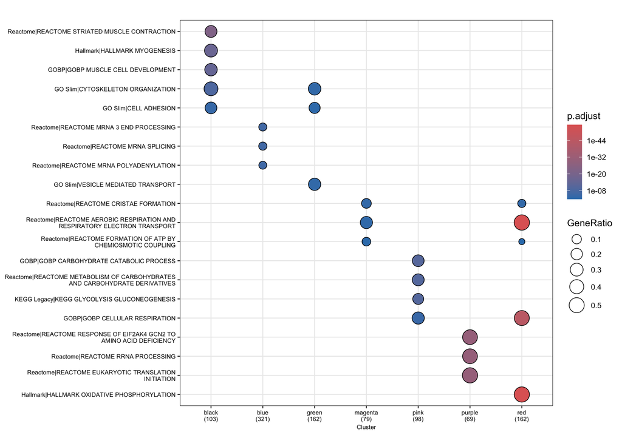

Figure 1: Leading sets per module at BH < 0.05. Size: gene ratio. Colour: BH within module.

```r
ora_fit |>
  clusterProfiler::filter(p.adjust < 0.05) |>
  enrichplot::dotplot(showCategory = 3, label_format = 50, font.size = 7)
```

## Top members

Each module’s ten members with the highest kME, the proteins that follow the module most closely.

```r
top_members <- members |>
  slice_max(kme, n = 10, by = module, with_ties = FALSE)
summarise(top_members, top_members = paste(gene, collapse = ", "), .by = module) |>
  head(4)
```

```
# A tibble: 4 × 2
  module    top_members
  <chr>     <chr>
1 turquoise PPP2R5A, SOD2, AIMP2, EPDR1, UBE2I, TRIM72, UTRN, CCT3, CAPZA1, BCA…
2 blue      ACTR2, HNRNPU, CLTC, AHNAK, TKT, CANX, CLIC1, CALR, ACTR3, IFITM1
3 brown     CUL4A, PYURF, CPPED1, PPP2R1A, SPR, MRPL9, TOMM7, UBE2L3, PTCD3, PR…
4 purple    RPLP0, RPL12, RPLP2, RPL7A, RPS16, RPL4, RPL19, VAPA, RPL13, RPL10A
```

## STRING interactions

STRINGdb maps the measured proteins to STRING identifiers and counts the high-confidence edges (combined score at least 700, STRING’s “high confidence” band) among each module’s members. The expected count accounts for each member’s number of partners in the background, which is the mapped measured proteins, not the whole proteome. A ratio above 1 means the members interact more than proteins drawn at random from this experiment. BH runs across modules. The mapping and the network edges come from the local STRING v12.0 files; `get_ppi_enrichment()` sends each module’s identifiers to the STRING web API, so this step needs network access, and STRING reports p below about 1e-16 as 0.

```r
string_db <- STRINGdb$new(
  version = "12.0", species = 9606, score_threshold = 700L,
  network_type = "full", input_directory = here(string_dir)
)
mapped <- string_db$map(as.data.frame(modules$membership), "uniprot_id", removeUnmappedRows = TRUE)
string_db$set_background(mapped$STRING_id)
```

[output not shown]

```r
string_check <- mapped |>
  filter(module != "grey") |>
  summarise(n_mapped = n(), ids = list(STRING_id), .by = module) |>
  mutate(
    enrichment = map(ids, string_db$get_ppi_enrichment),
    n_edges = map_dbl(enrichment, "edges"),
    n_expected = map_dbl(enrichment, "lambda"),
    ratio = n_edges / n_expected,
    p = map_dbl(enrichment, "enrichment"),
    fdr = p.adjust(p, "BH")
  ) |>
  select(-ids, -enrichment)
c(proteins = nrow(modules$membership), mapped = nrow(mapped))
```

```
proteins   mapped
    2059     2053
```

```r
arrange(string_check, desc(ratio))
```

```
      module n_mapped n_edges n_expected    ratio        p          fdr
1      black      109     432         57 7.578947 0.00e+00 0.0000000000
2       pink      103     147         34 4.323529 0.00e+00 0.0000000000
3        red      167    1948        602 3.235880 0.00e+00 0.0000000000
4      green      167     158         51 3.098039 0.00e+00 0.0000000000
5     purple       70     695        277 2.509025 0.00e+00 0.0000000000
6       blue      328     988        576 1.715278 0.00e+00 0.0000000000
7     yellow      211     178        123 1.447154 1.82e-06 0.0000026000
8    magenta       82      43         30 1.433333 1.67e-02 0.0167000000
9  turquoise      339     377        296 1.273649 3.17e-06 0.0000039625
10     brown      249     459        395 1.162025 8.70e-04 0.0009666667
```

## One label per module

```r
labels <- count(members, module, name = "n_proteins") |>
  left_join(
    ora |>
      slice_min(p, n = 1, by = module, with_ties = FALSE) |>
      select(module, top_set = pathway, top_set_fdr = fdr),
    by = "module"
  ) |>
  left_join(
    ora |>
      filter(collection == "GO_Slim") |>
      slice_min(p, n = 1, by = module, with_ties = FALSE) |>
      select(module, top_go_slim = pathway, go_slim_fdr = fdr),
    by = "module"
  ) |>
  left_join(
    summarise(top_members, top_members = paste(gene, collapse = ", "), .by = module),
    by = "module"
  ) |>
  left_join(select(string_check, module, string_ratio = ratio, string_fdr = fdr), by = "module") |>
  arrange(desc(n_proteins))
select(labels, module, n_proteins, top_set, top_set_fdr, string_ratio)
```

```
# A tibble: 10 × 5
   module    n_proteins top_set                         top_set_fdr string_ratio
   <chr>          <int> <chr>                                 <dbl>        <dbl>
 1 turquoise        340 sulfur compound metabolic proc…   1.000e+ 0         1.27
 2 blue             330 REACTOME_MRNA_3_END_PROCESSING    9.91 e- 7         1.72
 3 brown            249 GOBP_ESTABLISHMENT_OF_PROTEIN_…   5.98 e- 2         1.16
 4 yellow           211 GOBP_PROTEIN_MODIFICATION_BY_S…   1.03 e- 1         1.45
 5 green            168 cytoskeleton organization         4.05 e- 4         3.10
 6 red              167 REACTOME_AEROBIC_RESPIRATION_A…   6.48 e-56         3.24
 7 black            109 REACTOME_STRIATED_MUSCLE_CONTR…   1.85 e-23         7.58
 8 pink             104 GOBP_CARBOHYDRATE_CATABOLIC_PR…   1.76 e-11         4.32
 9 magenta           82 REACTOME_CRISTAE_FORMATION        2.36 e- 4         1.43
10 purple            70 REACTOME_RESPONSE_OF_EIF2AK4_G…   8.89 e-31         2.51
```

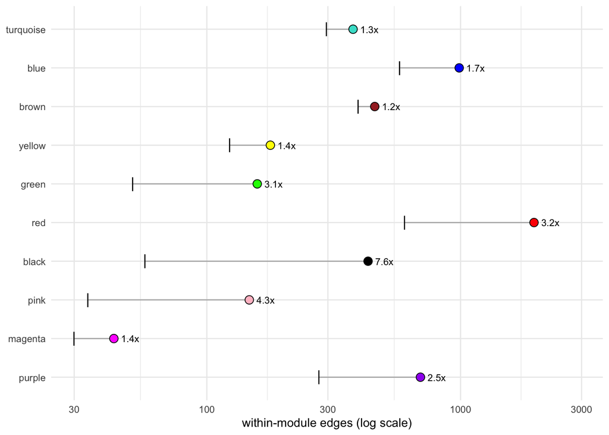

Figure 2: STRING edges within each module: point observed, tick expected, label the ratio.

```r
module_colours <- set_names(string_check$module, string_check$module)
string_check |>
  mutate(module = factor(module, levels = rev(labels$module))) |>
  ggplot(aes(y = module)) +
  geom_segment(aes(x = n_expected, xend = n_edges, yend = module), colour = "grey70") +
  geom_point(aes(x = n_expected), shape = 124, size = 4) +
  geom_point(aes(x = n_edges, fill = module), shape = 21, size = 3) +
  geom_text(aes(x = n_edges, label = sprintf("%.1fx", ratio)), hjust = -0.4, size = 2.8) +
  scale_fill_manual(values = module_colours, guide = "none") +
  scale_x_log10(expand = expansion(mult = c(0.05, 0.15))) +
  labs(x = "within-module edges (log scale)", y = NULL) +
  theme_minimal(base_size = 10)
```

## Networks of the top members

Each module’s 25 highest-kME members and the STRING edges among them, at the same 700 threshold. Node fill is kME; node size is the number of edges among the drawn members. Members with no edge are left out and counted in the panel title. The layout is force-directed and seeded; its geometry carries no meaning.

```r
network_nodes <- mapped |>
  filter(module != "grey") |>
  slice_max(kme, n = 25, by = module, with_ties = FALSE)
network_edges <- string_db$get_interactions(network_nodes$STRING_id) |>
  distinct(from, to, .keep_all = TRUE) |>
  inner_join(select(network_nodes, from = STRING_id, module), by = "from") |>
  inner_join(select(network_nodes, to = STRING_id, to_module = module), by = "to") |>
  filter(module == to_module) |>
  select(module, from, to, combined_score)
count(network_edges, module, name = "edges")
```

```
      module edges
1      black   101
2       blue    11
3      brown     8
4      green     8
5    magenta     7
6       pink    57
7     purple   230
8        red    75
9  turquoise     2
10    yellow     3
```

`draw_module_network()` takes one module’s colour and returns its network panel; it is called once per module.

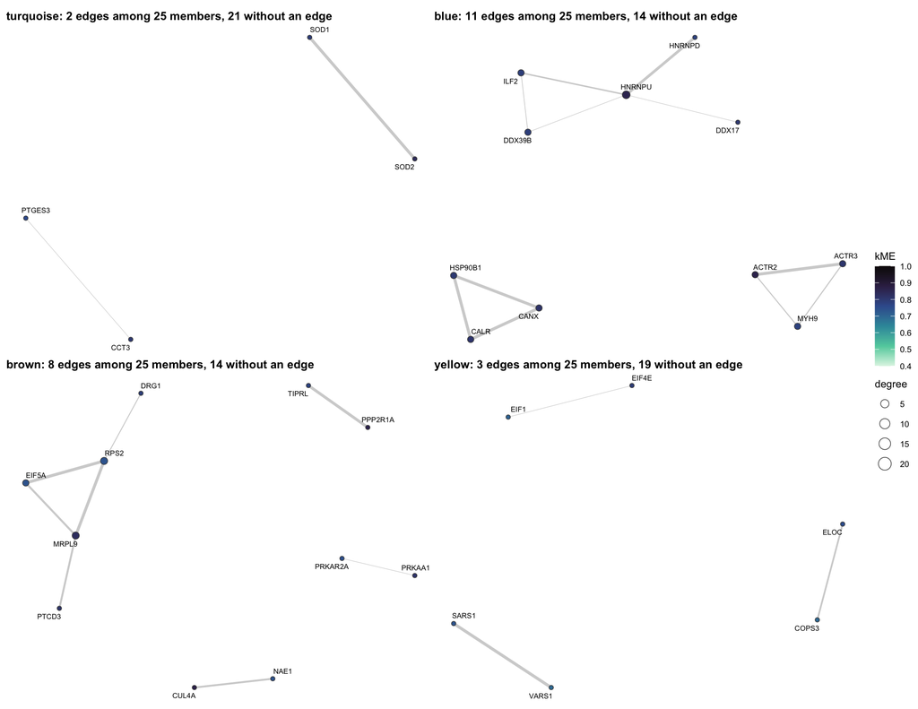

Figure 3: STRING edges among each module’s top 25 members by kME.

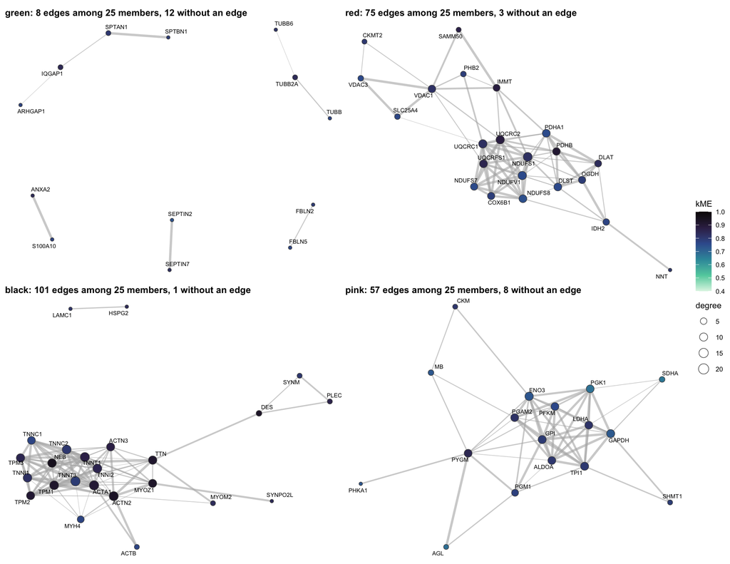

Figure 4: STRING edges among each module’s top 25 members by kME.

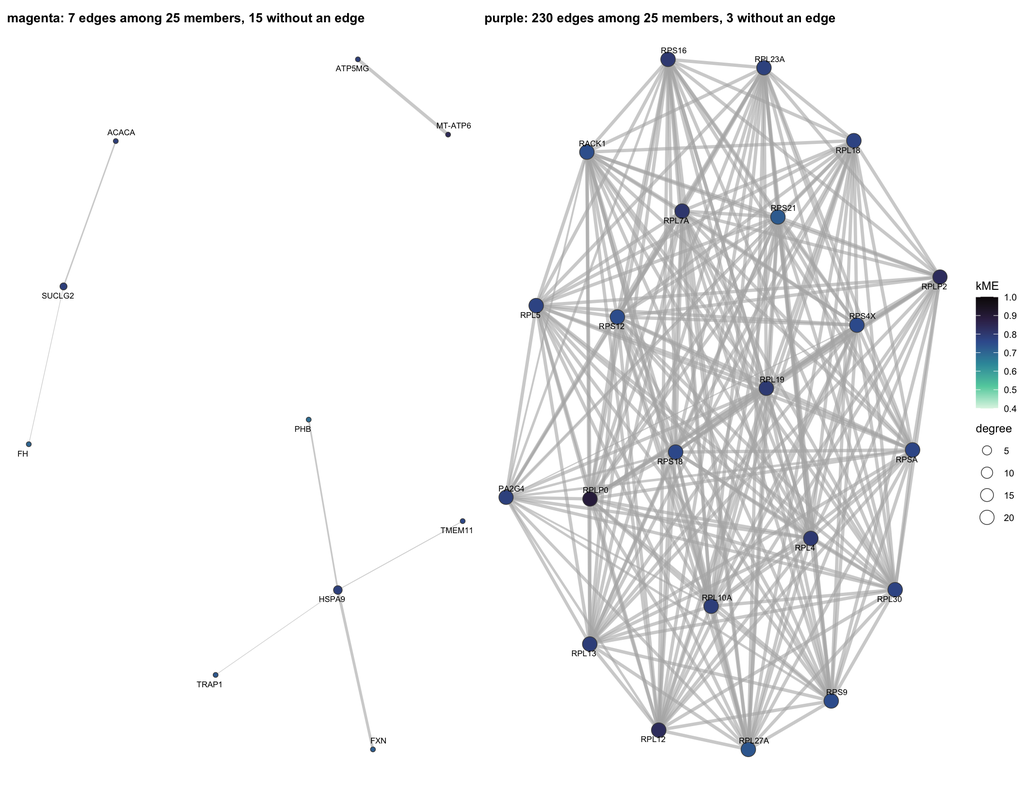

Figure 5: STRING edges among each module’s top 25 members by kME.

```r
max_degree <- max(table(c(network_edges$from, network_edges$to)))
draw_module_network <- function(which_module) {
  nodes <- network_nodes |>
    filter(module == which_module) |>
    transmute(name = STRING_id, gene, kme)
  edges <- network_edges |>
    filter(module == which_module) |>
    transmute(from, to, score = combined_score / 1000)
  graph <- nodes |>
    tidygraph::tbl_graph(edges = edges, directed = FALSE, node_key = "name") |>
    tidygraph::activate(nodes) |>
    mutate(degree = tidygraph::centrality_degree()) |>
    filter(degree > 0)
  isolated <- nrow(nodes) - igraph::vcount(graph)
  set.seed(42)
  ggraph::ggraph(graph, layout = "fr") +
    ggraph::geom_edge_link(aes(edge_width = score), colour = "grey70", alpha = 0.6) +
    ggraph::geom_node_point(aes(size = degree, fill = kme), shape = 21, colour = "grey30") +
    ggraph::geom_node_text(aes(label = gene), size = 2.2, repel = TRUE, max.overlaps = Inf) +
    ggraph::scale_edge_width(range = c(0.2, 1.2), guide = "none") +
    scale_fill_viridis_c(option = "mako", direction = -1, limits = c(0.4, 1), name = "kME") +
    scale_size_continuous(range = c(1.5, 5), limits = c(1, max_degree), name = "degree") +
    labs(title = sprintf(
      "%s: %d edges among %d members, %d without an edge", which_module, nrow(edges), nrow(nodes),
      isolated
    )) +
    theme_void(base_size = 9) +
    theme(plot.title = element_text(face = "bold", size = 10), legend.position = "right")
}
labels$module |>
  map(draw_module_network) |>
  split(ceiling(seq_along(labels$module) / 4)) |>
  walk(\(panels) print(wrap_plots(panels, ncol = 2, guides = "collect")))
```

## Validation

```r
stopifnot(
  setequal(labels$module, unique(members$module)),
  all(ora$fdr >= ora$p),
  all(network_edges$combined_score >= 700),
  all(top_members$module %in% labels$module)
)
```

## Summary

10 modules were characterised. 7 have at least one gene set at BH < 0.05, and 10 have more STRING edges among their members than expected at BH < 0.05.

## Save

The workbook holds every table above and is the reference for what each module colour means.

```r
out <- here("01_Processing", "07_Module_Characterisation", "c_data")
dir.create(out, showWarnings = FALSE)
sheets <- list(
  labels = labels, ora = arrange(ora, module, p), top_members = top_members, string = string_check,
  network_edges = left_join(network_edges,
    select(network_nodes, from = STRING_id, from_gene = gene),
    by = "from"
  ) |>
    left_join(select(network_nodes, to = STRING_id, to_gene = gene), by = "to")
)
holds <- c(
  "One row per module: size, top set, top GO Slim term, top members, STRING enrichment.",
  "clusterProfiler ORA of every module against the 04_Gene_Sets tested sets, BH within module.",
  "The ten highest-kME members of each module.",
  "STRINGdb PPI enrichment per module: observed and expected edges at score >= 700.",
  "STRING edges among each module's 25 highest-kME members, as drawn."
)
write_workbook(sheets, holds, file.path(out, "module_characterisation.xlsx"), inputs, paths)
```